# simon-5507-03-slides

## Topics to be covered

- What you will learn
  - Importing space-delimited files
  - Importing comma-delimited files
  - Importing tab-delimited files
  - Importing files with other delimiters
  - Importing files with strings
  - Fixed width files
  - Files with names in first row
  - Troubleshooting

## Defining a macro variable

- %let command
  - defines a macro value
- &macro_variable_name
  - substitutes that macro value in the code

## Simple example

```
%let row_limit=10;

(later on in your code)

proc print
    data=phase1(obs=&row_limit);

(this gets converted by SAS into)

proc print
    data=phase1(obs=10);
```

## When should you use a macro variable?

- Document important options at the top of your program
  - Quick and easy changes
- Reduce the amount of repetitive typing
- [Macro variables automatically available](https://documentation.sas.com/doc/en/pgmsascdc/9.4_3.5/mcrolref/p14ym6slnzfstzn1t9yp5v31ijis.htm)
  - My favorites, &sasdate and &sasver

## Text files

- Each row is a separate observation
- How to specify individual columns?
  - Blanks
  - Delimiters
  - Fixed width

## Importing choices

- Add options to the infile statement
- Use proc import
  - Especially useful when the first row includes variable names
  - Also useful for binary data files (e.g., Excel)
- Use proc sql (not covered in this class)
- Manual reformatting
  - Global search and replace
  - Not usually a good idea

## Options during data import

- Skipping rows
- Converting strings to numbers

## Space delimited, example

```
 4  8  40
 8 16  80
12 24 120
16 32 160
24 48 240
```

## Documentation header (1)

```
* 5507-03-simon-demo-01-space-delimited.sas
* author: Steve Simon
* creation date: 2019-07-01
* purpose: to import data with spaces as delimiters
* license: public domain;
```

## File locations (2)

```
%let path=q:/5507-2025b/03;

ods pdf file=
    "&path/results/5507-03-simon-demo-01-space-delimited.pdf";

libname perm
    "&path/data";

filename raw_data
    "&path/data/text-space-delimited.txt";
```

## Read space-delimited file (3)

```
data perm.space_delimited;
  infile raw_data;
  input x y z;
run;

proc print
    data=perm.space_delimited(obs=2);
  title1 "First two rows of data";
run;

ods pdf close;
```

## Live demo, 1

## Break #1

- What you have learned
  - Importing space-delimited files
- What’s coming next
  - Importing comma-delimited files

## A comma delimited file

```
4,8,40
8,16,80
12,24,120
16,32,160
24,48,240
```

## Documentation header (1)

```
* 5507-03-simon-demo-02-comma-delimited.sas
* author: Steve Simon
* creation date: 2019-07-01
* purpose: to import comma delimited files
* license: public domain;
```

## File locations (2)

```
%let path=q:/5507-2025b/03;

ods pdf file=
    "&path/results/5507-03-simon-demo-02-comma-delimited.pdf";

libname perm
    "&path/data";

filename raw_data
    "&path/data/text-comma-delimited.csv";
```

## Specifying a comma delimiter (3)

```
data perm.comma_delimited;
  infile raw_data delimiter=",";
  input x y z;
run;

proc print
    data=perm.comma_delimited(obs=2);
  title1 "First two rows of data";
run;

ods pdf close;
```

## Live demo, 2

- delimiter argument (infile subcommand, data step)

## Break #2

- What you have learned
  - Importing comma-delimited files
- What’s coming next
  - Importing tab-delimited files

## Tabs are evil

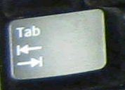

## The binary representation

- Tab character: Binary 0000 1001 or hexadecimal 09
- Space character: Binary 0010 0000 or hexadecimal 20
- Tabs and spaces look similar, but
  - A tab delimited file is not a space delimited file
  - A space delimited file is not a tab delimited file.

## Designations for the tab character

- “09”X
- ^t
- \t
- 0x09

## Epilog: The non-breaking space

- Looks just like a regular space
  - Does not allow word wrap
  - Does not allow multiple blanks to collapse
- Binary 1010 0000, Hexadecimal A0
- Represented in html as `&nbsp;`

## A tab delimited file

```
4   8   40
8   16  80
12  24  120
16  32  160
24  48  240
```

## Documentation header (1)

```
* 5507-03-simon-demo-03-tab-delimited.sas
* author: Steve Simon
* creation date: 2019-07-01
* purpose: to import a tab-delimited file into SAS
* license: public domain;
```

## File locations (2)

```
%let path=q:/5507-2025b/03;

ods pdf file=
    "&path/results/5507-03-simon-demo-03-tab-delimited.pdf";

libname perm
    "&path/data";

filename raw_data
  "&path/data/text-tab-delimited.txt";
```

## Specifying a tab delimiter (3)

```
data perm.tab_delimited;
  infile raw_data delimiter="09"X;
  input x y z;
run;

proc print
    data=perm.tab_delimited(obs=2);
  title1 "First two rows of data";
run;

ods pdf close;
```

## Live demo, 3

- “09”X (SAS code for the tab character)

## Break #3

- What you have learned
  - Importing tab-delimited files
- What’s coming next
  - Importing files with other delimiters

## A tilde delimited file

```
4~8~40
8~16~80
12~24~120
16~32~160
24~48~240
```

## Documentation header (1)

```
* 5507-03-simon-demo-04-tilde-delimited.sas
* author: Steve Simon
* creation date: 2019-07-01
* purpose: to import a tilde-delimited file into SAS
* license: public domain;
```

## File locations (2)

```
%let path=q:/5507-2025b/03;

ods pdf file=
    "&path/results/5507-03-simon-demo-04-tilde-delimited.pdf";

libname perm
  "&path/data";

filename raw_data
  "&path/data/text-tilde-delimited.txt";
```

## Specifying a tilde delimiter (3)

```
data perm.tilde_delimited;
  infile raw_data delimiter="~";
  input x y z;
run;

proc print
    data=perm.tilde_delimited(obs=2);
  title1 "First two rows of data";
run;

ods pdf close;
```

## Break #4

- What you have learned
  - Importing files with other delimiters
- What’s coming next
  - Importing files with strings

## String data

- A combination of letters, numbers, blanks, and/or symbols,
  - Examples
    - Simon, Stephen D.
    - 2411 Holmes Street
    - 816. 235-6617
- Also called character data
- Often enclosed in single quotes (`'`) or double quotes (`"`)
  - Avoid smart/curly quotes (`‘’` or `“”`)

## Cautions about strings

- Strings longer than 8 characters
- Strings that include delimiters
- Strings that include quote marks (Conan O’Brian)
- Symbols outside 7-bit ASCII
  - resumé, naïve, façade
- Strings with different alphabets

## A file with strings

```
Alpha,4,8
Bravo,8,16
Charlie,12,24
Delta,16,32
Echo,24,48
```

## Documentation header (1)

```
* 5507-03-simon-demo-05-string-data.sas
* author: Steve Simon
* creation date: 2019-07-02
* purpose: to import data that includes a string
* license: public domain;
```

## File locations (2)

```
%let path=q:/5507-2025b/03;

ods pdf file=
    "&path/results/5507-03-simon-demo-05-string-data.pdf";

libname perm
    "&path/data";

filename raw_data
    "&path/data/text-with-strings.txt";
```

## Reading string data (3)

```
data perm.string_data;
  infile raw_data delimiter=",";
  input
    name $
    x
    y;
run;

proc print
    data=perm.string_data(obs=2);
  title1 "First two rows of data";
run;

ods pdf close;
```

## Live demo, 5

## Break #5

- What you have learned
  - Importing files with strings
- What’s coming next
  - Fixed width files

## A fixed-width file

```
 4 8 40
 816 80
1224120
1632160
2448240
```

## Documentation header (1)

```
* 5507-03-simon-demo-06-fixed-width.sas
* author: Steve Simon
* creation date: 2019-07-01
* purpose: to import data in a fixed width format
* license: public domain;
```

## File locations (2)

```
%let path=q:/5507-2025b/03;

ods pdf file=
    "&path/results/5507-03-simon-demo-06-fixed-width.pdf";

libname perm
    "&path/data";

filename raw_data
    "&path/data/text-fixed-width.txt";
```

## Reading fixed width data (3)

```
data perm.fixed_width;
  infile raw_data delimiter=",";
  input
    x 1-2
    y 3-4
    z 5-7;
run;

proc print
    data=perm.fixed_width(obs=2);
  title1 "First two rows of data";
run;

ods pdf close;
```

## Break #6

- What you have learned
  - Fixed width files
- What’s coming next
  - Files with names in first row

## A file with names in the first line

```
name,x,y
Alpha,4,8
Bravo,8,16
Charlie,12,24
Delta,16,32
Echo,24,48
```

## Documentation header (1)

```
* 5507-03-simon-demo-07-first-line-names.sas
* author: Steve Simon
* creation date: 2019-07-02
* purpose: to import data with variable names on the first line
* license: public domain;
```

## File locations (2)

```
%let path=q:/5507-2025b/03;

ods pdf file=
    "&path/results/5507-03-simon-demo-07-first-line-names.pdf";

libname perm
    "&path/data";

filename raw_data
    "&path/data/text-first-line-names.csv";
```

## The import procedure (3)

```
proc import
    datafile=raw_data
    dbms=dlm
    out=perm.first_line_names
    replace;
  delimiter=",";
  getnames=yes;
run;

proc print
    data=perm.first_line_names(obs=2);
  title1 "First two rows of data";
run;

ods pdf close;
```

## Break #7

- What you have learned
  - Files with names in first row
- What’s coming next
  - Troubleshooting

## Troubleshooting

- Mistakes often will produce error or warning messages
  - Always check the log window!
- Using the wrong delimiter
  - Data smashed together in a single variable
- Misspecifying first line variable names
  - Strings as first line of data
  - Variable names are actually numbers
- Nonstandard missing value codes
  - Something other than dot (.)
  - Numeric data converted to strings

## Summary

- What you have learned
  - Importing space-delimited files
  - Importing comma-delimited files
  - Importing tab-delimited files
  - Importing files with other delimiters
  - Importing files with strings
  - Fixed width files
  - Files with names in first row
  - Troubleshooting